# Desafio Operações - Parte 2: Análise Exploratória

Marcelo Moraes

13/06/2019

Primeiro, os pacotes pertinentes devem ser instalados e abertos para utilização. Além disso, 3 variáveis relevantes ao processo de deflacionamento são criadas.

```r
require("BETS")
require("ggplot2")

anopassado<-as.numeric(format(Sys.Date(), "%Y"))-1
anopassadodata<-paste0(anopassado,"-01-01")
ultimotrianopassado<-paste0(anopassado,"-10-01")
```

O documento segue a metodologia de realizar download das séries relevantes com a função BETSget(), criar a base de dados quando relevante e, em seguida, realizar a visualização com a função ggplot(). Saldos, por representarem dinheiro, cujo valor varia com o tempo, serão deflacionados utilizando o IPCA, de modo que as visualizações sejam de saldos reais. Os códigos serão mostrados quando aparecerem pela primeira vez da forma utilizada e, nas próximas, serão omitidos. Entretanto, o código completo pode ser analisado através do arquivo “Análise Exploratória Geral.R”.

### Pontos de Atendimento: Brasil

Download das séries e criação da base de dados:

```r
qag<-BETSget(24887,data.frame=TRUE) #Agências
qag["value"]<-qag["value"]/1000
qag["name"]<-"Agências"
qpost<-BETSget(24893,data.frame=TRUE) #Postos de Atendimento
qpost["value"]<-qpost["value"]/1000
qpost["name"]<-"Postos de Atendimento"
qpostel<-BETSget(24899,data.frame=TRUE) #Postos de Atendimento Eletrônico
qpostel["value"]<-qpostel["value"]/1000
qpostel["name"]<-"Postos de Atendimento Eletrônico"
tipo_instalacao1<-rbind(qag,qpost,qpostel)
```

Visualização:

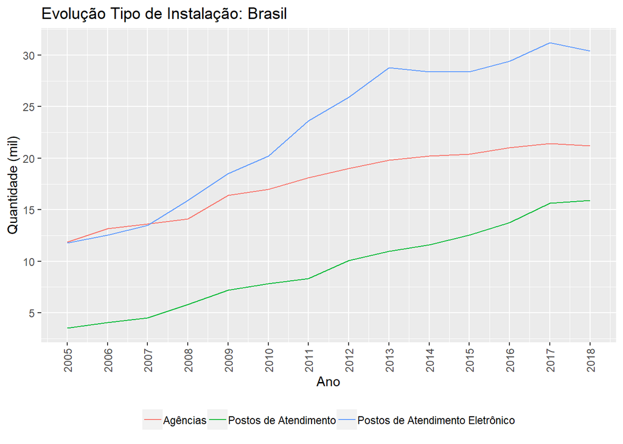

```r
ggplot()+
  geom_line(data=tipo_instalacao1,aes(x=date,y=value,color=name))+
  ggtitle("Evolução Tipo de Instalação: Brasil")+
  xlab("Ano")+
  ylab("Quantidade (mil)")+
  theme(axis.text.x = element_text(angle=90,vjust=0.5))+
  scale_x_date(breaks = "years",date_labels = "%Y")+
  scale_y_continuous(breaks=c(5,10,15,20,25,30))+
  theme(legend.position = "bottom",legend.title = element_blank())
```

Demais visualizações:

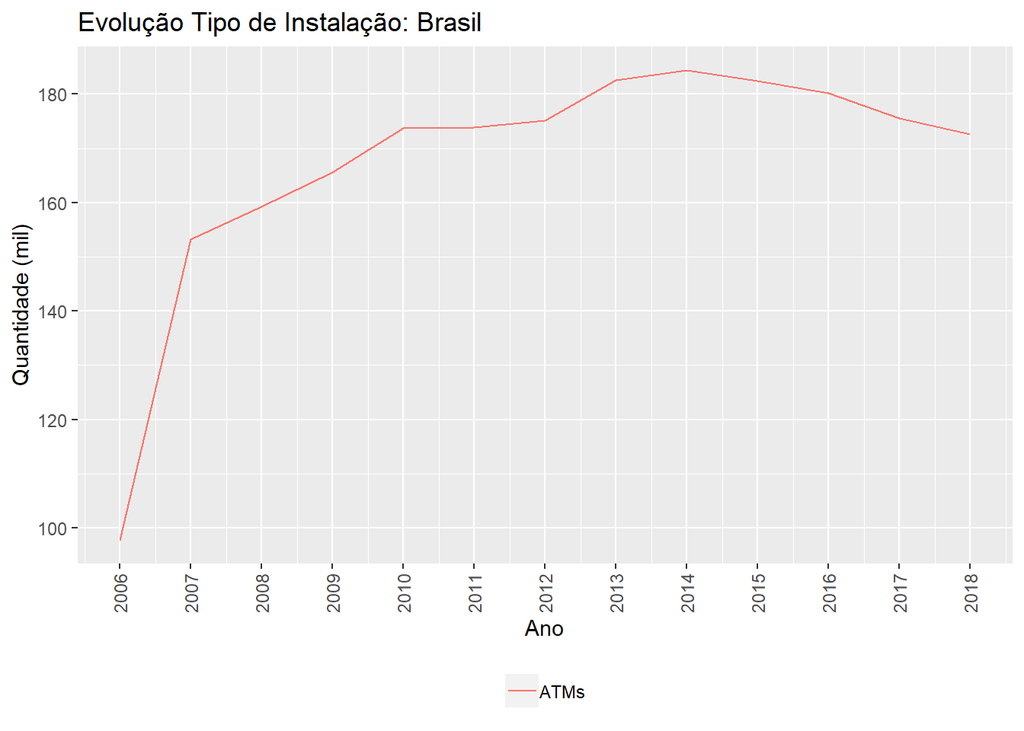

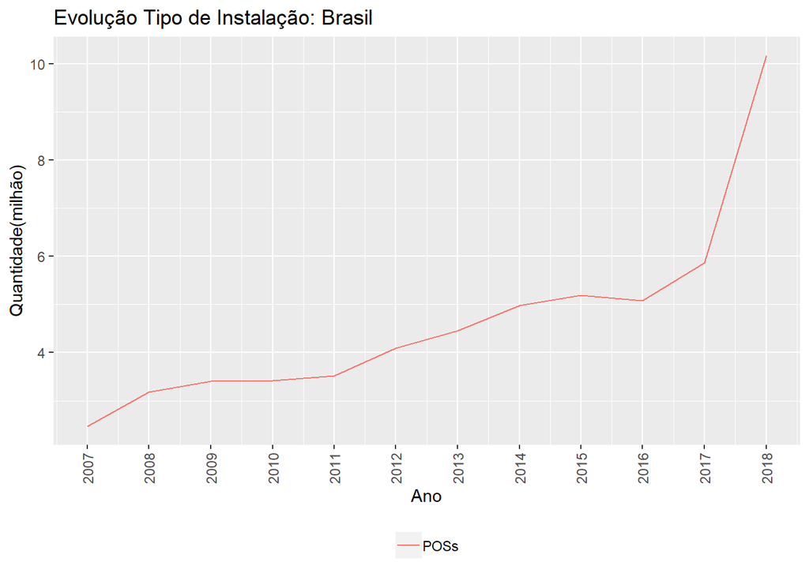

### Pontos de Atendimento: Por Região

Download das séries e criação da base de dados:

```r
series<-seq(24888,24892) #Agências
ag_reg<-NULL
for(i in series){
  assign(paste0("qag_",i),BETSget(i,data.frame=TRUE))
  ag_reg[[i]]<-get(paste0("qag_",i))
  }

a<-1
b<-nrow(qag_24888)

ag_reg_data<-do.call(rbind, ag_reg)
ag_reg_data[a:b,3]<-"Centro-Oeste"
ag_reg_data[(a+b*1):(b+b*1),3]<-"Nordeste"
ag_reg_data[(a+b*2):(b+b*2),3]<-"Norte"
ag_reg_data[(a+b*3):(b+b*3),3]<-"Sudeste"
ag_reg_data[(a+b*4):(b+b*4),3]<-"Sul"
ag_reg_data[,4]<-"agência"
colnames(ag_reg_data) <- c("date", "value","regiao","tipo")

series<-seq(24894,24898) #postos de Atendimento
post_reg<-NULL
for(i in series){
  assign(paste0("qpost_",i),BETSget(i,data.frame=TRUE))
  post_reg[[i]]<-get(paste0("qpost_",i))
}

a<-1
b<-nrow(qpost_24894)

post_reg_data<-do.call(rbind, post_reg)
post_reg_data[a:b,3]<-"Centro-Oeste"
post_reg_data[(a+b*1):(b+b*1),3]<-"Nordeste"
post_reg_data[(a+b*2):(b+b*2),3]<-"Norte"
post_reg_data[(a+b*3):(b+b*3),3]<-"Sudeste"
post_reg_data[(a+b*4):(b+b*4),3]<-"Sul"
post_reg_data[,4]<-"posto de atendimento"
colnames(post_reg_data) <- c("date", "value","regiao","tipo")

series<-seq(24900,24904) #Postos de Atendimento Eletrônico
postel_reg<-NULL
for(i in series){
  assign(paste0("qpostel_",i),BETSget(i,data.frame=TRUE))
  postel_reg[[i]]<-get(paste0("qpostel_",i))
}

a<-1
b<-nrow(qpostel_24900)

postel_reg_data<-do.call(rbind, post_reg)
postel_reg_data[a:b,3]<-"Centro-Oeste"
postel_reg_data[(a+b*1):(b+b*1),3]<-"Nordeste"
postel_reg_data[(a+b*2):(b+b*2),3]<-"Norte"
postel_reg_data[(a+b*3):(b+b*3),3]<-"Sudeste"
postel_reg_data[(a+b*4):(b+b*4),3]<-"Sul"
postel_reg_data[,4]<-"posto de atendimento\neletrônico"
colnames(postel_reg_data) <- c("date", "value","regiao","tipo")

#Contruindo base de dados 1 completa
tipo_reg_data1<-rbind(ag_reg_data,post_reg_data,postel_reg_data)
```

Visualização:

[figure not shown]

```r
ggplot()+
  geom_line(data=tipo_reg_data1,aes(x=date,y=value),color="dark green")+
  ggtitle("Evolução Tipo de Instalação")+
  xlab("Ano")+
  ylab("Quantidade")+
  theme(axis.text.x = element_text(angle=90,vjust=0.5))+
  scale_x_date(breaks = "years",date_labels = "%Y")+
  theme(legend.position = "bottom",legend.title = element_blank())+
  facet_grid(tipo ~ regiao, scales="free")
```

Demais visualizações:

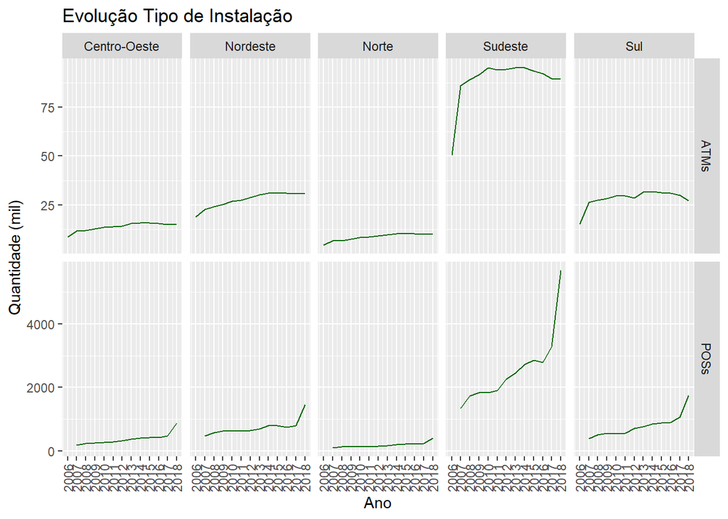

### Correspondente por Atividade Autorizada

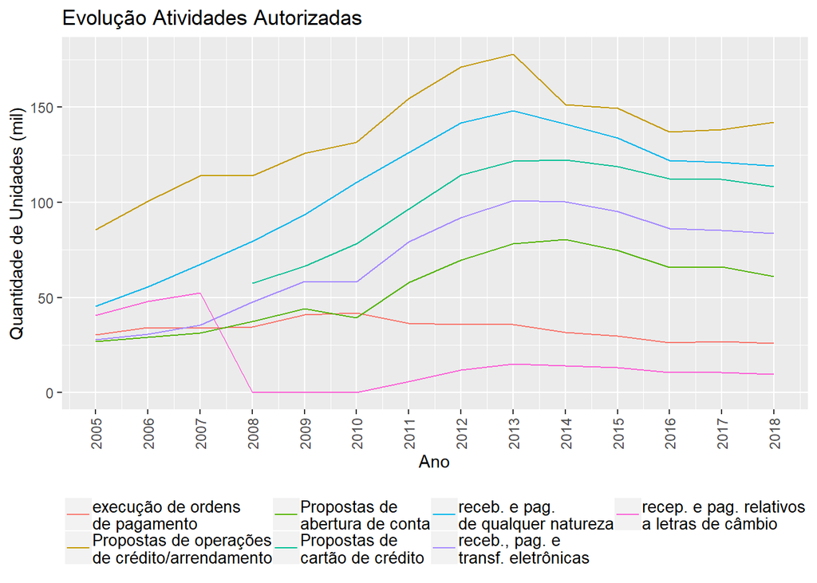

### Clientes Detentores de Contas

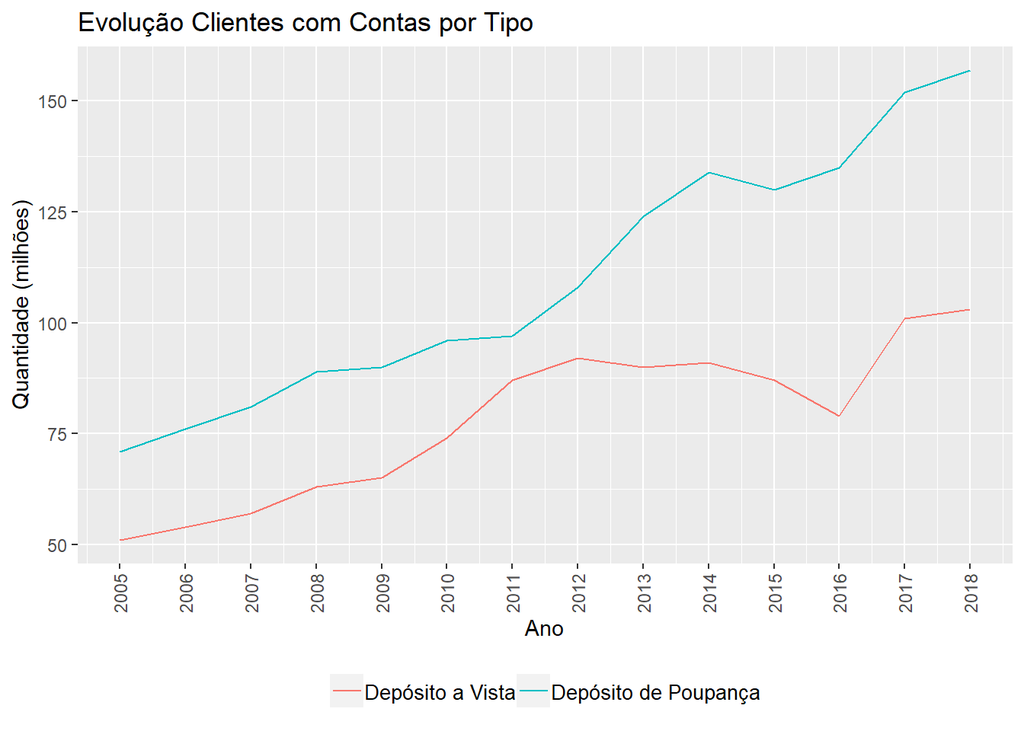

### Adultos com Relacionamento Bancário por Faixa Etária e % de Adultos com Relacionamento Bancário

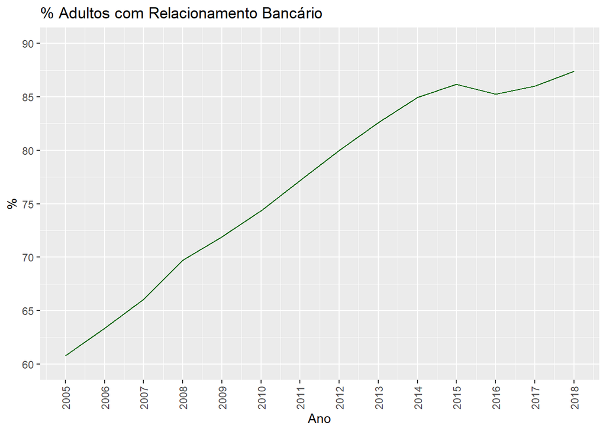

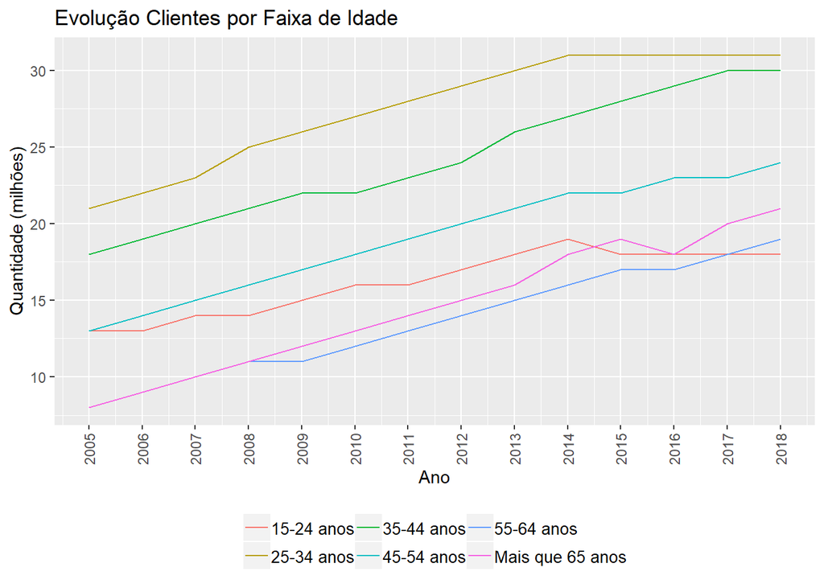

### Quantidade de Microempreendedores Individuais com Relacionamento na Pessoa Jurídica

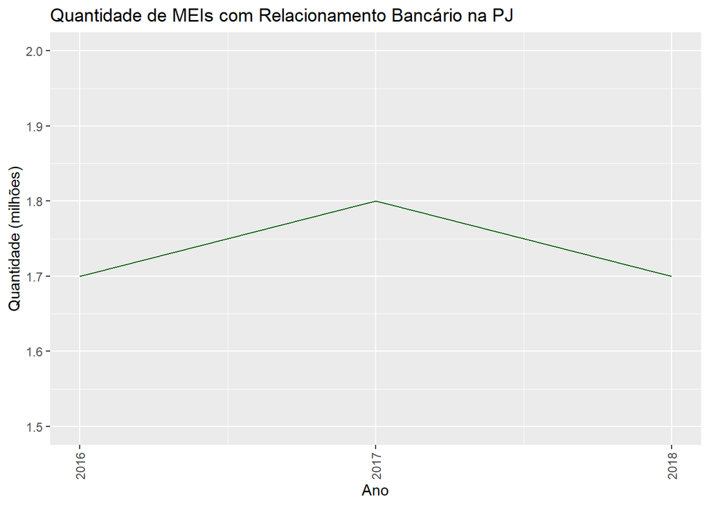

### Saldo Real de Contas de Depósito a Vista

Gerando índice para deflacionar:

```r
ipca<-BETSget(433,data.frame=TRUE,from = "2005-01-01", to = anopassadodata )
ipca[nrow(ipca),3]<-1

i=nrow(ipca)-1
while(i!=0){
  ipca[i,3]<-ipca[i+1,3]*(1+ipca[i,2]/100)
  i<-i-1
}
colnames(ipca)<-c("date", "value", "index")

ipca_index_ano<-NULL
aux<-anopassado-2005
for(i in 0:aux){
  ipca_index_ano<-rbind(ipca_index_ano,ipca[1+(12*i),])
}
```

Download da série, deflacionamento e visualização:

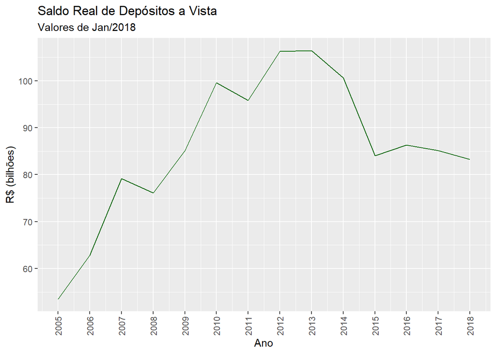

```r
saldo_dv<-BETSget(25133,data.frame=TRUE) #Saldo de contas de depósito a vista
saldo_dv["value"]<-saldo_dv["value"]/1000
saldo_dv["real_value"]<-saldo_dv["value"]*ipca_index_ano["index"] #Deflacionando

ggplot()+
  geom_line(data=saldo_dv,aes(x=date,y=real_value),color="dark green")+
 labs(title = "Saldo Real de Depósitos a Vista", subtitle = paste0("Valores de Jan/",anopassado))+
  xlab("Ano")+
  ylab("R$ (bilhões)")+
  theme(axis.text.x = element_text(angle=90,vjust=0.5))+
  scale_x_date(breaks = "years",date_labels = "%Y")+
  theme(legend.position = "bottom",legend.title = element_blank())
```

### Cartões de Débito e Crédito Emitidos e Ativos

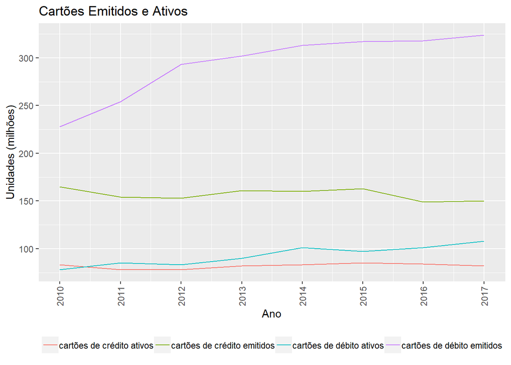

### Transações por Instrumento de Pagamento e Saldo Real das Transações

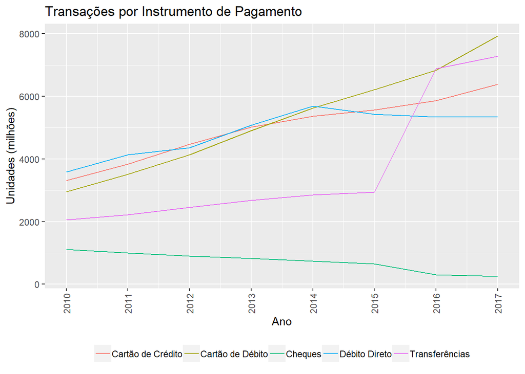

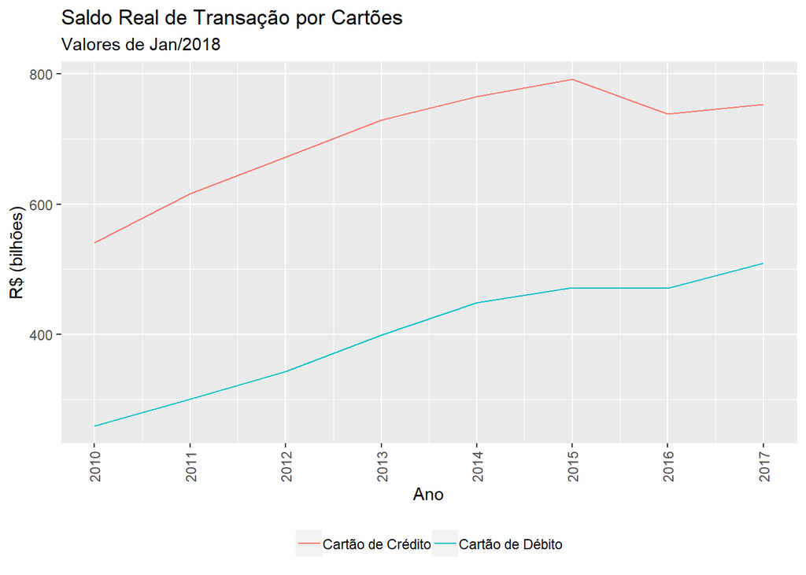

### Quantidade de Transações por Tipo: Presencial e Não Presencial

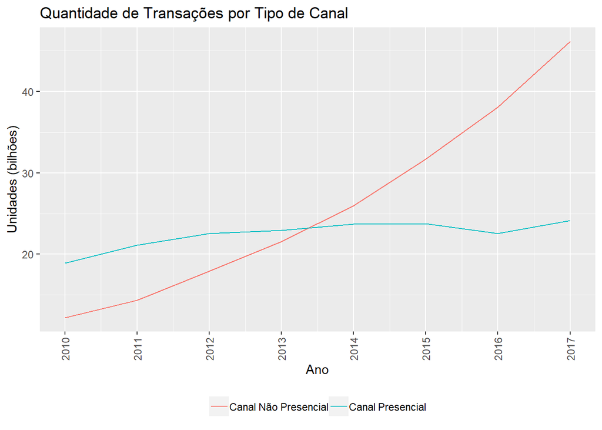

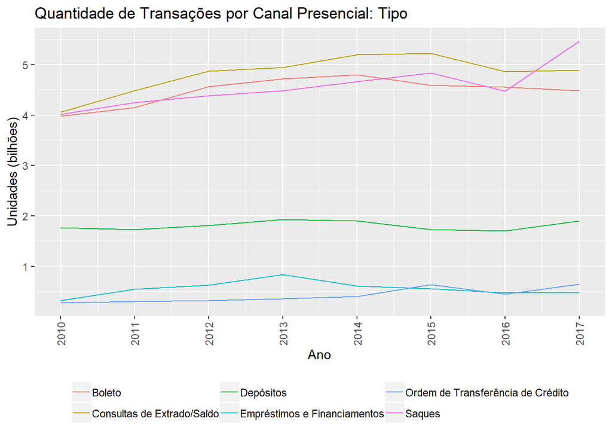

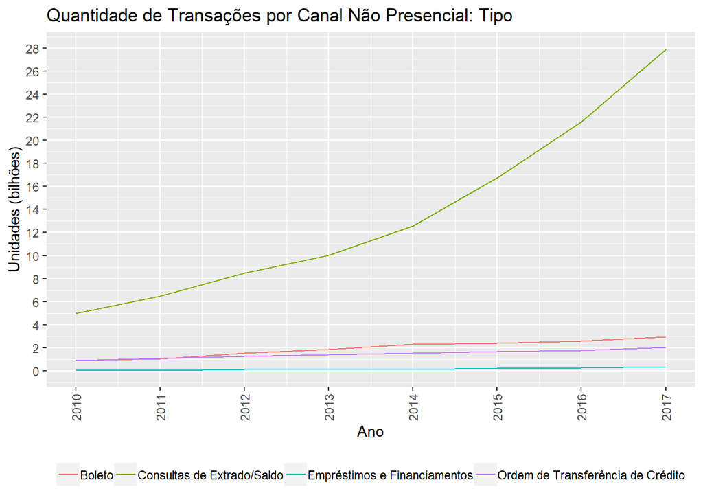